# cfDNA Fragmentation Analysis in ALS and Control Plasma Samples

ML Mansego

# 1 Introduction

Cell-free DNA (cfDNA) in plasma originates predominantly from apoptotic and necrotic cellular processes. The resulting fragmentation pattern reflects nucleosomal architecture and chromatin accessibility, providing valuable insights into tissue-specific cell death and disease-associated molecular changes. In the context of amyotrophic lateral sclerosis (ALS), cfDNA has emerged as a potential non-invasive biomarker under active investigation. Fragmentation characteristics—particularly insert size distributions—may capture signals related to disease-specific cell turnover, inflammatory processes, or epigenomic alterations.

The present analysis investigates differences in cfDNA fragmentation patterns between ALS patients and healthy controls, based on insert size distributions derived from EM-seq data. Fragment size profiles are quantified using insert size metrics obtained through Picard tools and compared across groups to identify disease-associated patterns.

# 2 Metadata Loading

The sample metadata, including subject ID, condition (ALS or control), age, gender, and ALS phenotype (bulbar or spinal, for patients only), is imported and used to stratify insert size data.

# 3 Insert Size Analysis

## 3.1 Extraction and Preprocessing

Insert size data were extracted from Picard output files. Only fragment lengths ≤ 600 bp were retained for biological relevance.

## 3.2 Nucleosome Peak Abundance Analysis

In this section, peak cfDNA fragment sizes associated with mono-, di-, and trinucleosomes were identified within predefined size ranges. For each nucleosome category, the fragment size showing the highest mean abundance was selected separately for ALS and control groups.

To assess potential differences in peak fragment abundance between conditions, the Wilcoxon rank-sum test was applied to each size range. A summary table was generated, presenting the mean and standard deviation of fragment counts per group, along with the corresponding p-values from the statistical tests.

This analysis was performed to explore whether specific nucleosome-associated cfDNA fragments differ in abundance between ALS and controls, which may reflect alterations in chromatin structure or cell death dynamics.

```r
# This script identifies peak nucleosome fragment sizes in different ranges
# and compares their abundance between conditions (ALS vs Control)

## Define nucleosome size ranges
# We analyze three nucleosome configurations:
ranges <- list(
  "Mono" = c(120, 170),   # Mononucleosomes (core particle + short linker)
  "Di"   = c(280, 350),   # Dinucleosomes
  "Tri"  = c(430, 600)    # Trinucleosomes
)

## Find peak abundances for each condition and range

peaks_by_condition <- lapply(names(ranges), function(r) {
  fragment_summary %>%
    filter(insert_size >= ranges[[r]][1], insert_size <= ranges[[r]][2]) %>%
    group_by(Condition) %>%
    slice_max(mean_count, n = 1, with_ties = FALSE) %>%
    mutate(Nucleosome_Type = r) %>%
    select(Condition, Nucleosome_Type, insert_size, mean_count, sd_count)
}) %>% bind_rows()

## 3. Test (Wilcoxon)
stat_results <- lapply(names(ranges), function(nuc) {
  range <- ranges[[nuc]]
  test <- fragment_summary %>%
    filter(insert_size >= range[1], insert_size <= range[2]) %>%
    wilcox.test(mean_count ~ Condition, data = ., exact = FALSE)
  data.frame(Nucleosome_Type = nuc, p_value = test$p.value)
}) %>% bind_rows() %>%
  mutate(p_value = ifelse(p_value < 0.001, "< 0.001", round(p_value, 3)))

## 4. summary by nucleosome and condition
table_data <- peaks_by_condition %>%
  mutate(Count_SD = paste0(round(mean_count, 2), " (", round(sd_count, 2), ")")) %>%
  select(Nucleosome_Type, Condition, Count_SD) %>%
  pivot_wider(names_from = Condition, values_from = Count_SD) %>%
  left_join(stat_results, by = "Nucleosome_Type") %>%
  select(Nucleosome_Type, ALS, Control, p_value)

## 5. table
table_data %>%
  kable("latex",
        booktabs = TRUE,
        col.names = c("Nucleosome Type", "Bulbar", "Spinal", "p-value"),
        caption = "Table 2. Summary of peak nucleosome-associated cfDNA fragment counts by condition.") %>%
  kableExtra::kable_styling(latex_options = c("hold_position", "striped"))
```

[output not shown]

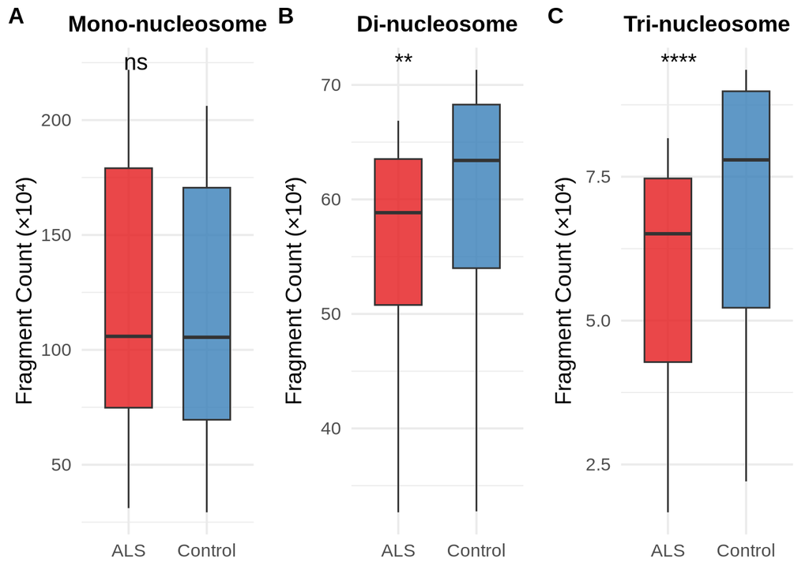

```r
##  Boxplot visualization

fragment_plot_data <- fragment_summary %>%
  filter(insert_size >= 120 & insert_size <= 600) %>%
  mutate(Nucleosome_Type = case_when(
    insert_size >= 120 & insert_size <= 170 ~ "Mono",
    insert_size >= 280 & insert_size <= 350 ~ "Di",
    insert_size >= 430 & insert_size <= 600 ~ "Tri",
    TRUE ~ NA_character_
  )) %>%
  filter(!is.na(Nucleosome_Type))


fragment_plot_data_scaled <- fragment_plot_data %>%
  mutate(mean_count_scaled = mean_count / 10000)

plot_nuc_type_scaled <- function(nuc_type) {
  df <- fragment_plot_data_scaled %>% filter(Nucleosome_Type == nuc_type)

  ggplot(df, aes(x = Condition, y = mean_count_scaled, fill = Condition)) +
    geom_boxplot(width = 0.6, alpha = 0.8) +
    stat_compare_means(method = "wilcox.test", label = "p.signif", size = 5) +
    labs(
      title = paste0(nuc_type, "-nucleosome"),
      x = NULL,
      y = "Fragment Count (×10⁴)"
    ) +
    scale_fill_brewer(palette = "Set1") +
    theme_minimal(base_size = 14) +
    theme(
      plot.title = element_text(face = "bold", size = 14, hjust = 0.5),
      legend.position = "none",
      plot.margin = margin(10, 10, 10, 10)
    )
}


p_mono <- plot_nuc_type_scaled("Mono")
p_di   <- plot_nuc_type_scaled("Di")
p_tri  <- plot_nuc_type_scaled("Tri")


final_plot <- ggarrange(p_mono, p_di, p_tri,
                        ncol = 3,
                        labels = c("A", "B", "C"),
                        align = "v")

print(final_plot)
```

```r
ggsave("figures/Nucleosome_Peak_Abundance_ALSvsCT.png", final_plot,
       width = 8, height = 5, dpi = 300, bg = "white")
```

## 3.3 Visualization of Fragment Size Distribution

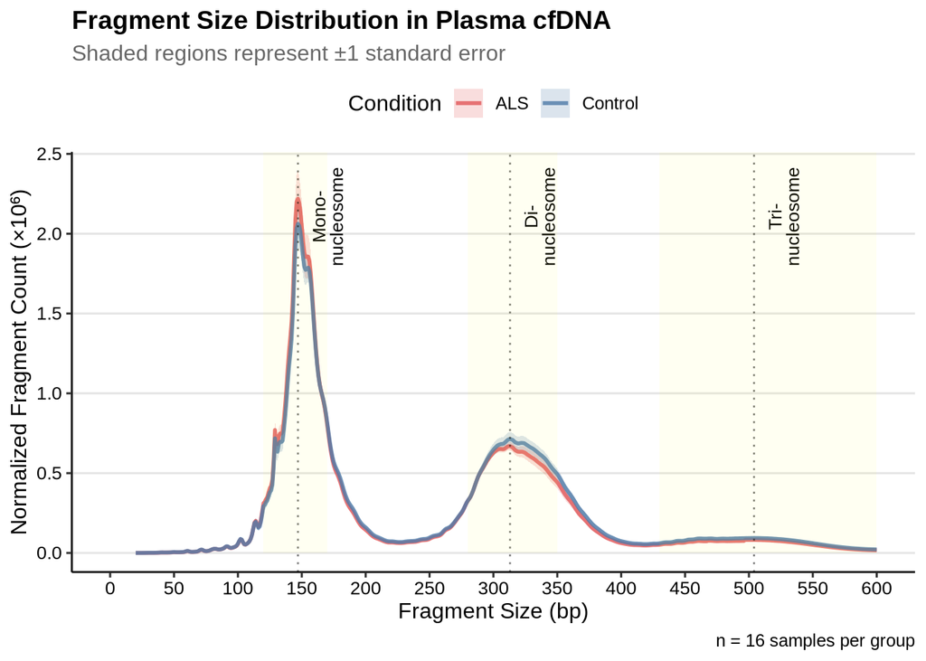

Mean fragment size distribution by group

### 3.3.1 Short-to-Long Fragment Ratio Analysis

Fragment size distributions in cfDNA are shaped by nucleosomal protection and degradation dynamics. Short fragments (~110–150 bp) typically originate from apoptotic cleavage, while longer fragments (~200–600 bp) may reflect alternative modes of cell death or reduced chromatin degradation. The relative abundance of these fragment populations can provide insight into underlying biological processes.

Previous studies have proposed the short-to-long fragment ratio as a potential biomarker in cfDNA-based analyses. Therefore, in this section, the abundance of short and long fragments was quantified for each sample, and the corresponding short-to-long fragment ratio was calculated. All values were normalized per million fragments and compared between ALS and control groups.

#### 3.3.1.1 Distribution of Short-to-Long Ratios

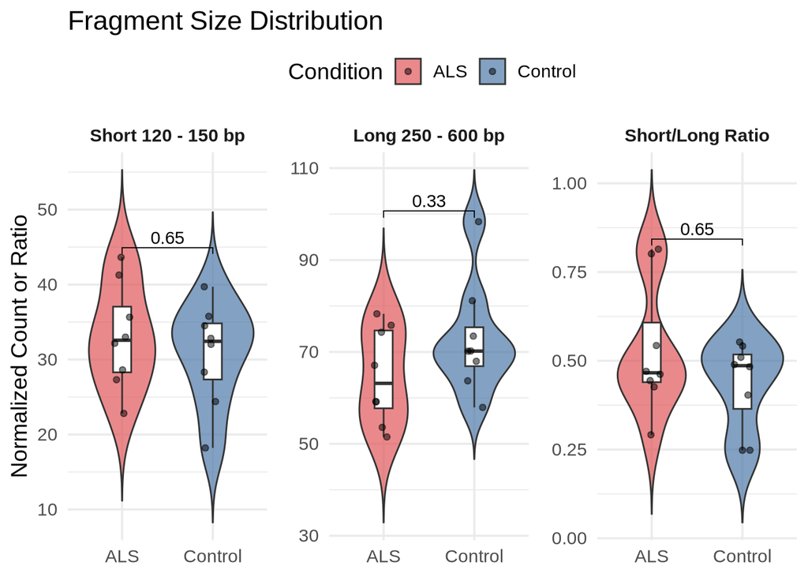

Short-to-long fragment ratio by condition

ALS samples showed a non-significant trend toward higher abundance of short fragments and reduced levels of long fragments compared to controls. Consequently, the short-to-long ratio appeared slightly elevated in the ALS group. While these tendencies are biologically plausible—potentially reflecting increased apoptotic cfDNA release—they did not reach statistical significance and should be interpreted with caution.

## 3.4 Fragmentation Differences Between Bulbar- and Spinal-Onset ALS

Within the ALS group, patients can present distinct onset phenotypes: bulbar or spinal. These phenotypes may reflect different neurodegenerative mechanisms and progression patterns. Here, we examine whether cfDNA fragmentation differs between bulbar- and spinal-onset ALS patients.

## 3.5 Nucleosome Peak Abundance Analysis (Bulbar vs Spinal onset ALS)

```r
# Nucleosome Peak Abundance Analysis
# This script identifies peak nucleosome fragment sizes in different ranges
# and compares their abundance between conditions (ALS vs Control)

## Define nucleosome size ranges
# We analyze three nucleosome configurations:
ranges <- list(
  "Mono" = c(120, 170),   # Mononucleosomes (core particle + short linker)
  "Di"   = c(280, 350),   # Dinucleosomes
  "Tri"  = c(430, 600)    # Trinucleosomes
)

## Find peak abundances for each condition and range

peaks_by_pheno <- lapply(names(ranges), function(r) {
  fragment_pheno_summary %>%
    filter(insert_size >= ranges[[r]][1], insert_size <= ranges[[r]][2]) %>%
    group_by(ALS_Phenotype) %>%
    slice_max(mean_count, n = 1, with_ties = FALSE) %>%
    mutate(Nucleosome_Type = r) %>%
    select(ALS_Phenotype, Nucleosome_Type, insert_size, mean_count, sd_count)
}) %>% bind_rows()

## 3. Test (Wilcoxon)
stat_results_ALS <- lapply(names(ranges), function(nuc) {
  range <- ranges[[nuc]]
  test <- fragment_pheno_summary %>%
    filter(insert_size >= range[1], insert_size <= range[2]) %>%
    wilcox.test(mean_count ~ ALS_Phenotype, data = ., exact = FALSE)
  data.frame(Nucleosome_Type = nuc, p_value = test$p.value)
}) %>% bind_rows() %>%
  mutate(p_value = ifelse(p_value < 0.001, "< 0.001", round(p_value, 3)))

## 4. summary by nucleosome and condition
table_data_ALS <- peaks_by_pheno %>%
  mutate(Count_SD = paste0(round(mean_count, 2), " (", round(sd_count, 2), ")")) %>%
  select(Nucleosome_Type, ALS_Phenotype, Count_SD) %>%
  pivot_wider(names_from = ALS_Phenotype, values_from = Count_SD) %>%
  left_join(stat_results_ALS, by = "Nucleosome_Type") %>%
  select(Nucleosome_Type, Bulbar, Spinal, p_value)

## 5. table
table_data_ALS %>%
  kable("latex",
        booktabs = TRUE,
        col.names = c("Nucleosome Type", "Bulbar", "Spinal", "p-value"),
        caption = "Table 1. Summary of peak nucleosome-associated cfDNA fragment counts by ALS phenotype.") %>%
  kableExtra::kable_styling(latex_options = c("hold_position", "striped"))
```

[output not shown]

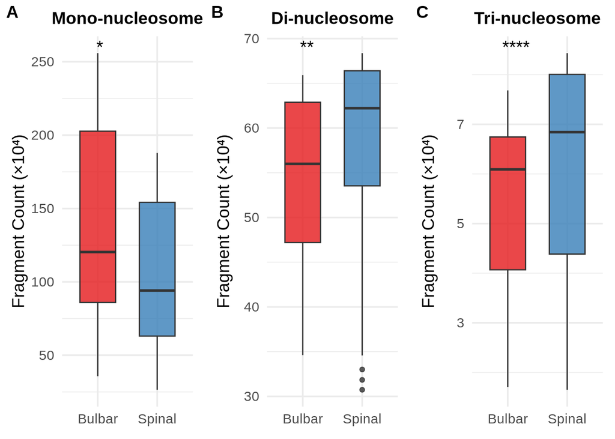

```r
##  Boxplot visualization

fragment_plot_data_ALS <- fragment_pheno_summary %>%
  filter(insert_size >= 120 & insert_size <= 600) %>%
  mutate(Nucleosome_Type = case_when(
    insert_size >= 120 & insert_size <= 170 ~ "Mono",
    insert_size >= 280 & insert_size <= 350 ~ "Di",
    insert_size >= 430 & insert_size <= 600 ~ "Tri",
    TRUE ~ NA_character_
  )) %>%
  filter(!is.na(Nucleosome_Type))

fragment_plot_data_scaled_ALS <- fragment_plot_data_ALS %>%
  mutate(mean_count_scaled = mean_count / 10000)

plot_nuc_type_scaled <- function(nuc_type) {
  df <- fragment_plot_data_scaled_ALS %>% filter(Nucleosome_Type == nuc_type)

  ggplot(df, aes(x = ALS_Phenotype, y = mean_count_scaled, fill = ALS_Phenotype)) +
    geom_boxplot(width = 0.6, alpha = 0.8) +
    stat_compare_means(method = "wilcox.test", label = "p.signif", size = 5) +
    labs(
      title = paste0(nuc_type, "-nucleosome"),
      x = NULL,
      y = "Fragment Count (×10⁴)"
    ) +
    scale_fill_brewer(palette = "Set1") +
    theme_minimal(base_size = 14) +
    theme(
      plot.title = element_text(face = "bold", size = 14, hjust = 0.5),
      legend.position = "none",
      plot.margin = margin(10, 10, 10, 10)
    )
}

p_mono <- plot_nuc_type_scaled("Mono")
p_di   <- plot_nuc_type_scaled("Di")
p_tri  <- plot_nuc_type_scaled("Tri")

final_plot_ALS <- ggarrange(p_mono, p_di, p_tri,
                        ncol = 3,
                        labels = c("A", "B", "C"),
                        align = "v")

print(final_plot_ALS)
```

```r
ggsave("figures/Nucleosome_Peak_Abundance_BvsS.png", final_plot_ALS,
       width = 8, height = 5, dpi = 300, bg = "white")
```

### 3.5.1 Fragment Size Distribution by ALS Phenotype

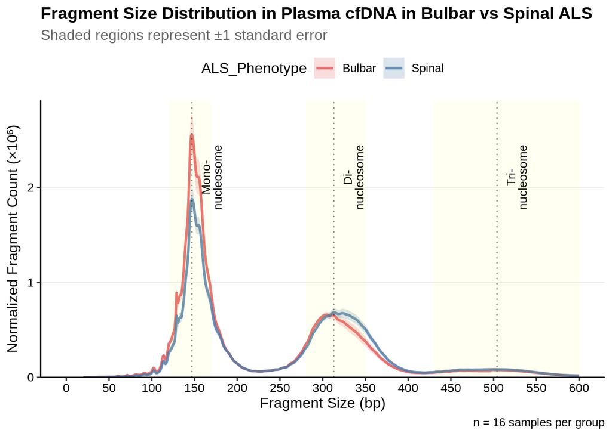

Fragment size distribution in bulbar- vs spinal-onset ALS

### 3.5.2 Short-to-Long Fragment Ratio Analysis

As described previous sections, the short-to-long fragment ratio was also evaluated within the ALS group to compare ALS phenotypes, aiming to explore potential differences in fragmentation patterns associated with clinical presentation.

# 4 Summary and Interpretation

Nucleosomal cfDNA fragmentation patterns were assessed in ALS patients and healthy controls. No significant differences were observed in mononucleosomal fragment abundance between groups; however, ALS samples showed significantly lower levels of di- and tri-nucleosomal fragments, suggesting enhanced cfDNA fragmentation or altered chromatin processing in ALS.

In line with these findings, ALS samples also exhibited a non-significant trend toward a higher abundance of short fragments and a reduced abundance of long fragments, resulting in an increased short-to-long fragment ratio. Although this difference was not statistically significant, it is consistent with a shift toward apoptotic cfDNA release in ALS.

# 5 Conclusion

This study provides a preliminary characterization of cfDNA fragmentation patterns in ALS plasma samples using EM-seq data. Although no significant differences were detected between ALS and control groups in overall fragmentation metrics, a selective reduction in di- and tri-nucleosomal fragments was observed in ALS samples, suggesting increased cfDNA degradation or altered chromatin processing.